# Documenting an R Script: Synthetic Sales Summary

Sudheer Kumar Aki

2026-10-30

> **AI Assistance Declaration:** I used ChatGPT (GPT-6, October 30, 2026) to suggest structure and formatting. Prompts are listed in `AI_Prompts_Appendix.md`. I must verify all explanations and run/knit the document myself. All final calculations are my responsibility.

# Purpose

This document explains an R script that simulates 12 sales orders, calculates totals by region, and displays a bar chart. All records are synthetic.

- A fixed random seed (`400`) for reproducibility.
- Three fictional regions: East, West, and Central.
- Twelve simulated sales amounts between 50 and 250 units.
- No uploaded data files or external dependencies for analysis.

## Data Preparation

```r
set.seed(400)
sales <- data.frame(
  order_id = seq_len(12),
  region = rep(c("East", "West", "Central"), each = 4),
  amount = round(runif(12, min = 50, max = 250), 2)
)
head(sales)
```

```
##   order_id region amount
## 1        1   East  79.99
## 2        2   East  87.08
## 3        3   East 196.16
## 4        4   East 122.92
## 5        5   West 235.92
## 6        6   West 130.36
```

## Processing and Summary

The base R `aggregate()` function adds order amounts within each region.

```r
region_totals <- aggregate(amount ~ region, data = sales, FUN = sum)
print(region_totals)
```

```
##    region amount
## 1 Central 446.82
## 2    East 486.15
## 3    West 616.23
```

## Outputs

The main outputs are a region-level summary table and a simple bar chart.

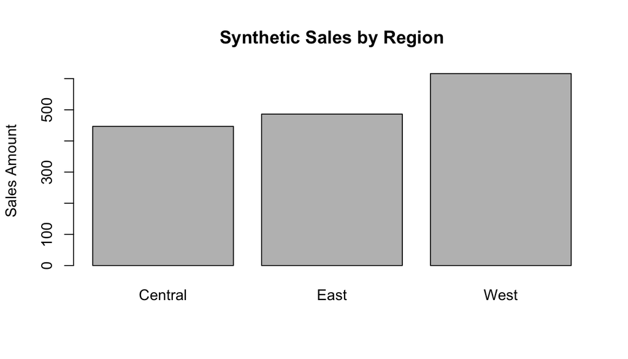

```r
barplot(region_totals$amount,
        names.arg = region_totals$region,
        main = "Synthetic Sales by Region",
        ylab = "Sales Amount")
```

## Interpretation and Validation

- Check that 12 rows are generated and there are four orders per region.
- Confirm the sum of the regional totals equals the sum of all 12 sales amounts.
- Confirm the three bars correspond to the three summary rows.
- Run **Knit** in RStudio and inspect the rendered headings, R code, table, and figure.

```r
stopifnot(nrow(sales) == 12)
stopifnot(all(table(sales$region) == 4))
stopifnot(isTRUE(all.equal(sum(region_totals$amount), sum(sales$amount))))
```

## Limitations

This is a teaching example, not an estimate of real sales. Any conclusions should be limited to the simulated values.